# ECOM90024 - Assignment 3 - Question 3

Josh Copeland

2024-05-22

```r
# Packages used for this assignment

# library(tidyverse)
# library(lubridate)
# library(forecast)
```

# Question 3

The file “aapl.csv” contins observations of the daily closing price of Apple from 15/05/2015 to 15/05/2019. Uing *R* you are required to do the following:

## a) Generate the daily returns of Apple’s stock price as the log difference of the daily closing price. Plot the data and provide a brief description of the observed time series.

Chart 1 shows a chart of Apple’s daily returns from 2015-05-15 to 2019-05-14. The mean of this series looks to be constant over time, but there is clear evidence of volatility clustering throuhgout this period. Notably, this occurs in late 2015, as well as early and late 2018 to call out the biggest examples (but there are other smaller episode throughout this history).

This volatility clustering suggests this time series has a conditional variance, where a (G)ARCH specification would likely aid in modelling these returns. However, more analysis is required to confirm this.

```r
################################# IMPORTING DATA ###############################

data <- read_csv("aapl.csv") %>%
  select(date, price = aapl) %>%
  mutate(

    date = dmy(date),
    returns = (log(price) - lag(log(price))) * 100

    ) %>%
  na.omit()
```

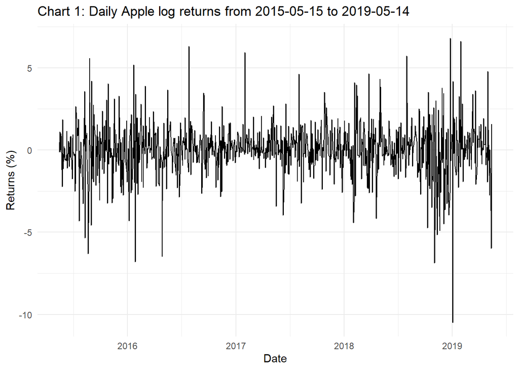

```r
################################# CHARTING DATA ###############################

ggplot(data, aes(date, returns)) +
  geom_line() +
  ggtitle("Chart 1: Daily Apple log returns from 2015-05-15 to 2019-05-14")+
  ylab("Returns (%)") +
  xlab("Date")
```

## b) Using the methodology outlined in previous lectures, specify and estimate an appropriate and parsimonious model for the conditional mean of the daily returns. Do not include any deterministic trend or seasonal dummies in your specification.

```r
#################### SPECIFYING THE NUMBER OF MAX ADF LAGS #####################

kmax <- ceiling(12*(length(data$price_level)/100)^(1/4))
############################## ADF TEST ON LEVEL SERIES ########################


for (i in 1:(kmax-1)){

  k = kmax+1-i

  df_data_level = ur.df(data$returns, type = "none", lags = k)

  tstat = df_data_level@testreg$coefficients[k+1,3]

  if(abs(tstat) >= 1.6){break}

}

k
```

```
## [1] 0
```

```r
# SUMMARY OF ADF TEST

summary(df_data_level)
```

```
##
## ###############################################
## # Augmented Dickey-Fuller Test Unit Root Test #
## ###############################################
##
## Test regression none
##
##
## Call:
## lm(formula = z.diff ~ z.lag.1 - 1)
##
## Residuals:
##      Min       1Q   Median       3Q      Max
## -10.4942  -0.5877   0.0615   0.8331   6.8467
##
## Coefficients:
##         Estimate Std. Error t value Pr(>|t|)
## z.lag.1 -0.98417    0.03157  -31.17   <2e-16 ***
## ---
## Signif. codes:  0 '***' 0.001 '**' 0.01 '*' 0.05 '.' 0.1 ' ' 1
##
## Residual standard error: 1.582 on 1004 degrees of freedom
## Multiple R-squared:  0.4918, Adjusted R-squared:  0.4913
## F-statistic: 971.8 on 1 and 1004 DF,  p-value: < 2.2e-16
##
##
## Value of test-statistic is: -31.1732
##
## Critical values for test statistics:
##       1pct  5pct 10pct
## tau1 -2.58 -1.95 -1.62
```

```r
# Conclusion: The test statistic is very large (~-31). Therefore, we can reject the null hypothesis at any reasonable significance level and conclude this series is I(O).
```

- Next we need to confirm our series is not white noise before specifying any mean equation with an ARIMA model. If they are white noise, this series cannot be usefully modelled using such a process.
  - Using our portmanteau tests below, we conclude it is not suitable to use an ARIMA process to model the conditional mean of this series.

  +This is because the p-values from both our tests are both very large, meaning we cannot reject the null hypothesis of there being no autocorrelation in the time series up to 32 lags (m). This means these series are effectively white noise.

```r
m <- ceiling((sqrt(length(data$returns))))

m
```

```
## [1] 32
```

```r
Box.test(data$returns, lag = m, type = "Box-Pierce")
```

```
##
##  Box-Pierce test
##
## data:  data$returns
## X-squared = 39.28, df = 32, p-value = 0.176
```

```r
Box.test(data$returns, lag = m, type = "Ljung-Box")
```

```
##
##  Box-Ljung test
##
## data:  data$returns
## X-squared = 40.049, df = 32, p-value = 0.1552
```

- Because we’ve concluded these series are effectively white noise, we can skip generating the the ACF and PACF to determine its dependence structure (there is none). From this we generate the conditional mean equation as an ARIMA(0,0,0)

```r
mean_eqn <- Arima(data$returns,
                     order = c(0,0,0),
                     include.mean = FALSE,
                     method = "CSS-ML")
```

## c) Using your estimates from part b, compute and plot h-step ahead dpoint and 95% interval forecasts for the daily returns for h = 1, 2, …, 10.

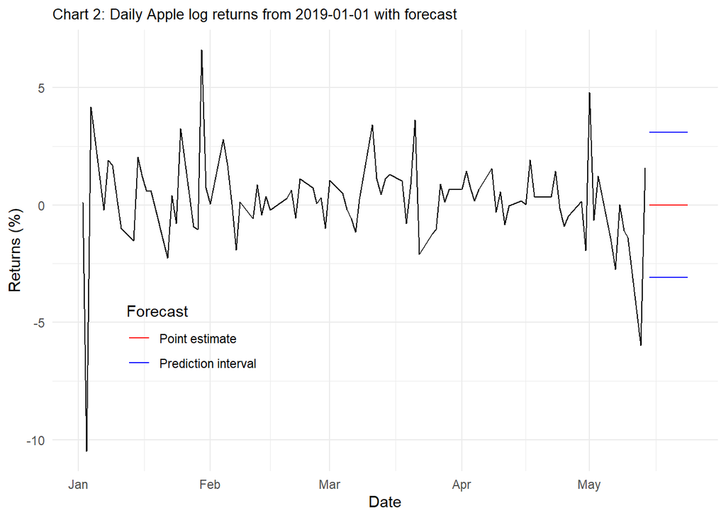

```r
################################# FORECASTING VALUES ###########################

mean_fc <- forecast(mean_eqn, h = 10) %>%
   data.frame() %>%
  select(point_estimate = Point.Forecast, low_prediction_interval = Lo.95, high_prediction_interval = Hi.95)

############################ CREATING DATAFRAME FOR FORECASTING ################

data_fc <- data.frame(date = seq(from = max(data$date) + days(1), by = "days", length.out = 10)) %>%
  cbind(mean_fc)

############################ COMBINING TOGETHER FOR CHART ######################

data_final <- data %>%
  full_join(data_fc, by = "date") %>%
  filter(date >= "2019-01-01")


################################### CHART ######################################


mean_eqn_fc <- ggplot(data_final, aes(x = date)) +
  geom_line(aes(y = returns)) +
  geom_line(aes(y = point_estimate, colour = "Point estimate")) +
  geom_line(aes(y = high_prediction_interval, colour = "Prediction interval")) +
  geom_line(aes(y = low_prediction_interval, colour = "Prediction interval")) +


    scale_colour_manual(name = "Forecast", values = c("Point estimate" = "red", "Prediction interval" = "blue")) +

    ggtitle("Chart 2: Daily Apple log returns from 2019-01-01 with forecast")+
  ylab("Returns (%)") +
  xlab("Date") +
      theme(plot.title = element_text(size = 10),
        plot.caption = element_text(hjust = 0),
        legend.position = c(0.1, 0.4),
        legend.justification = c(0, 1))
mean_eqn_fc
```

## d) Using the method described in lecture 9, test for the presence of ARCH effects in the residuals obtained from the conditional mean estimated in part (b).

- Before estimating, its worth noting that Chart 3 indicates residuals with high degrees of volatility clustering. This just reflects the returns series as we did not actually modell the mean with an ARIMA(0,0,0).
- Chart 4 and Chart 5 show the ACF and PACF respectively of the squared residuals from our conditional mean equation, both of which show many significant lags, telling us that ARCH effects are present.
- This is confirmed by the portmanteau tests below on the squared residuals from our conditional mean equation, which confirm these series are not white noise, and that there is indeed dependence in the squared residuals of our conditional mean equation. This justifies us pursuing the estimation of an ARCH/GARCH model.

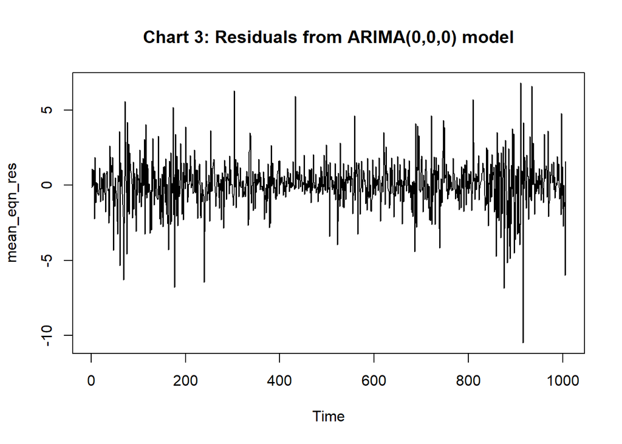

```r
mean_eqn_res <- mean_eqn$resid

plot(mean_eqn_res, main = "Chart 3: Residuals from ARIMA(0,0,0) model")
```

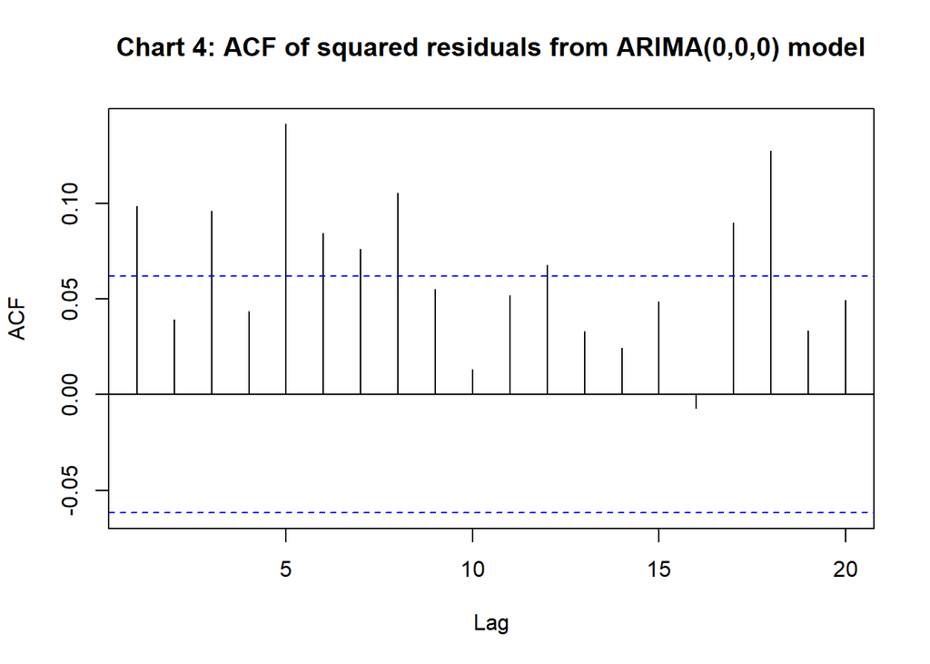

```r
mean_eqn_res_sq <- mean_eqn_res^2

acf.res <- acf(mean_eqn_res_sq, plot = FALSE)
pacf.res <- pacf(mean_eqn_res_sq, plot = FALSE)

plot(acf.res[1:20], main = "Chart 4: ACF of squared residuals from ARIMA(0,0,0) model")
```

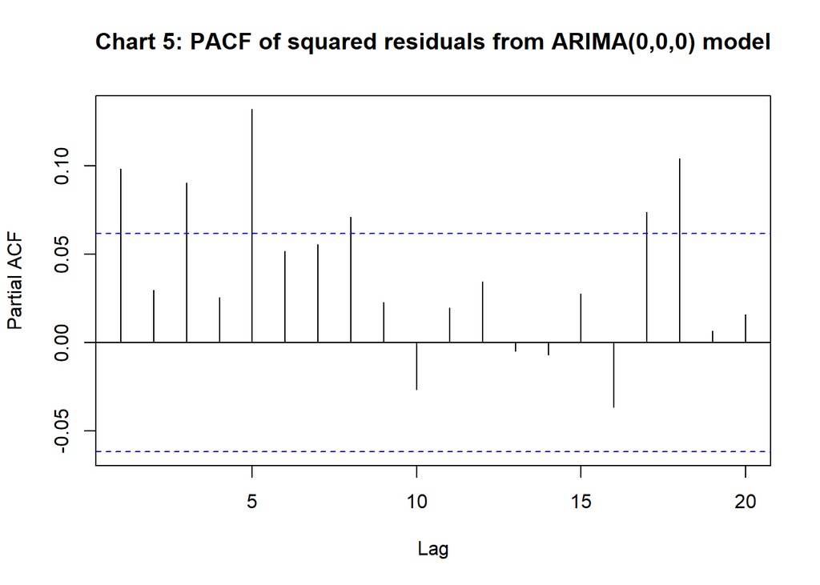

```r
plot(pacf.res[1:20], main = "Chart 5: PACF of squared residuals from ARIMA(0,0,0) model")
```

```r
Box.test(mean_eqn_res_sq, type = "Box-Pierce", l = m)
```

```
##
##  Box-Pierce test
##
## data:  mean_eqn_res_sq
## X-squared = 139.68, df = 32, p-value = 2.109e-15
```

```r
Box.test(mean_eqn_res_sq, type = "Ljung-Box", l = m)
```

```
##
##  Box-Ljung test
##
## data:  mean_eqn_res_sq
## X-squared = 141.74, df = 32, p-value = 8.882e-16
```

## e) Estimate an appropriate ARCH/GARCH model for the innovations. Verify that your specification is adequate.

- From Chart 4 above, it can be seen there are significant ACF lags up to lag 18. Therefore, we will test for model with ARCH terms up to order 18.
- AIC and BIC disagree on which model to use (ARCH(12) and ARCH(8)) respectively. We will go with the more parsimonious ARCH(8) model.
- After estimating the ARCH(8) model we rexamine the residuals and note the residuals now look much more like white noise (Chart 6). This is confirmed by our portmanteau tests below in the squared standardised squared residuals. Given their large p-values, we can confirm the residuals from this model are now white noise.
- Therefore, we conclude this ARCH(8) model successfully accounts for the ARCH effects in this return series.
- However, we also test to see if a more parsimonious GARCH(1,1) sufficiently arrives at the same solution and instead prefer this specification: the residuals also look very similar and like white noise (Chart 8) and the portmanteau tests also confirm this is the case for the same reason as above.

```r
########################### ESTIMATING ARCH MODELS #############################

z = 18

prefix.arch <- "arch"
suffix.arch <- seq(1,z)

arch.label <- paste(prefix.arch, suffix.arch, sep = "" )

arch.info <- data.frame(row.names = arch.label, matrix(NA,z,2))

colnames(arch.info) <- c("aic","bic")

T <- length(mean_eqn_res)

for(i in 1:z){
archmod <- garch(mean_eqn_res, order = c(0,i))
arch.info[i,1] <- AIC(archmod)
arch.info[i,2] <- AIC(archmod, k = log(T-i-1))
}
```

[output not shown]

[output cut: 1397 more lines]

```r
akaike.choice <- rownames(arch.info)[which.min(arch.info[,1])]
bayes.choice <- rownames(arch.info)[which.min(arch.info[,2])]

akaike.choice
```

```
## [1] "arch12"
```

```r
bayes.choice
```

```
## [1] "arch8"
```

```r
########################## REXAMINING RESIDUALS ################################


archmod <- garch(mean_eqn_res, order = c(0,8))
```

[output not shown]

[output cut: 86 more lines]

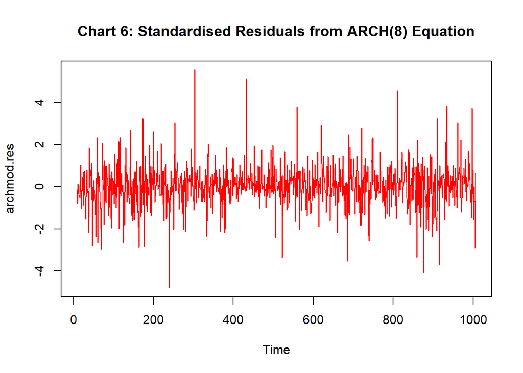

```r
archmod.res <- archmod$residuals

archmod.res <- na.omit(archmod.res)

plot(archmod.res, col = "red", main = "Chart 6: Standardised Residuals from ARCH(8) Equation", type = "l")
```

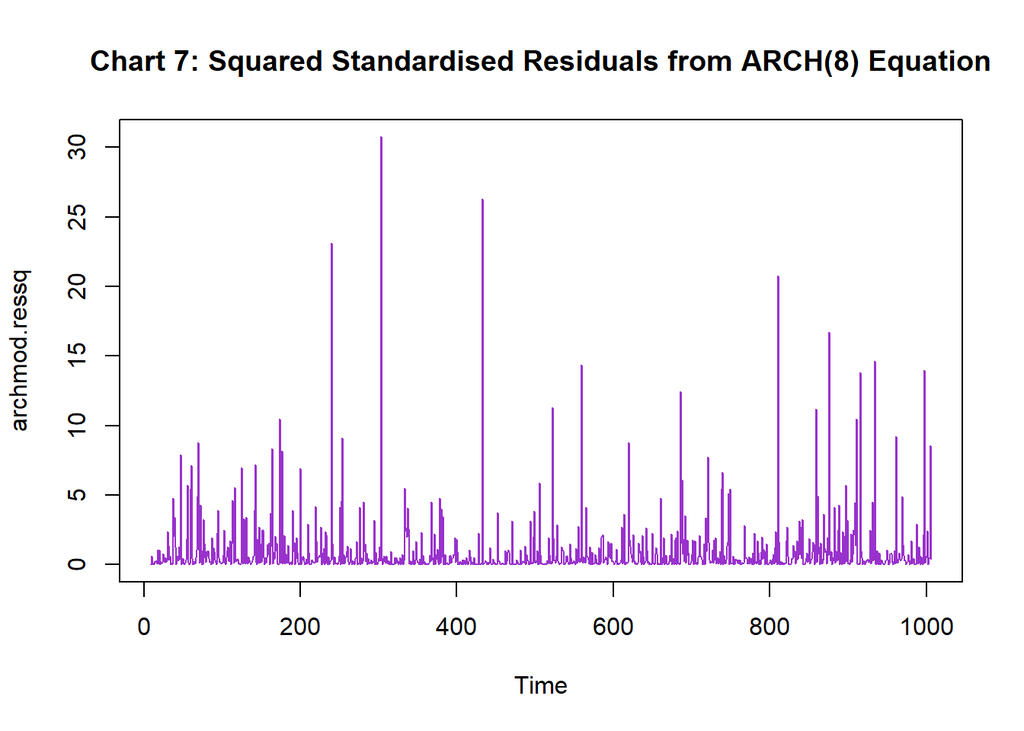

```r
archmod.ressq <- archmod.res^2

plot(archmod.ressq, col = "darkorchid", main = "Chart 7: Squared Standardised Residuals from ARCH(8) Equation", type = "l")
```